# OJ-Purchase-Prediction

Nikhil Prema Chandra Rao

2024-10-27

# Introduction

In this analysis, we aim to predict whether a customer will purchase **Citrus Hill** or **Minute Maid** orange juice using the **OJ** dataset from the `ISLR2` library. We will develop a **Decision Tree** model and explore its accuracy in predicting customer purchases. We will also visualize the decision-making process, inspect feature importance, and improve the model through hyperparameter tuning. The goal is to provide a comprehensive, step-by-step explanation using R code and visualizations.

## Data Loading and Preprocessing

```r
# Load necessary libraries
library(ISLR2)
library(caret)
```

```r
library(rpart)
library(rpart.plot)
library(ggplot2)
library(dplyr)
# Load the OJ dataset
data(OJ)

# Check for missing values
sum(is.na(OJ))
```

```
## [1] 0
```

```r
# Convert Purchase to a factor
OJ$Purchase <- as.factor(OJ$Purchase)
```

In this section, we load the necessary libraries such as ISLR2 (for the dataset), caret (for data partitioning and model tuning), rpart (for decision tree modeling), and ggplot2 for data visualization.

We check for any missing values in the dataset and convert the response variable Purchase into a factor, which is essential for classification tasks.

## Data Splitting

To evaluate the model, we split the dataset into training and testing sets. This ensures that the model is trained on one subset of the data and then tested on unseen data for an unbiased evaluation.

```r
# Split the data into training (70%) and testing (30%) sets
set.seed(123)
train_index <- createDataPartition(OJ$Purchase, p = 0.7, list = FALSE)
train_data <- OJ[train_index, ]
test_data <- OJ[-train_index, ]
```

## Exploratory Data Analysis (EDA)

### Distribution of Purchases

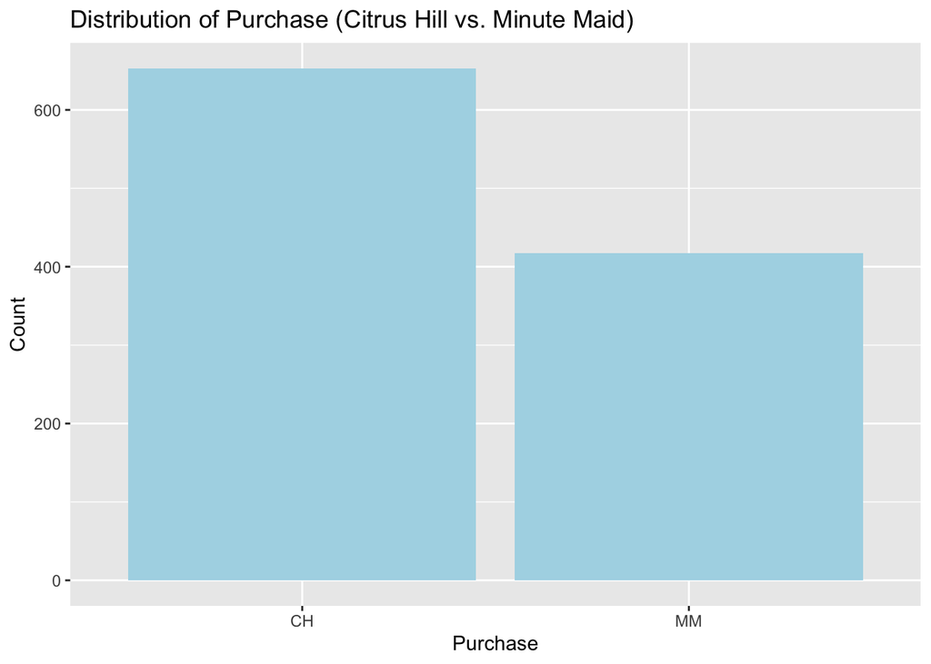

```r
ggplot(OJ, aes(x = Purchase)) +
  geom_bar(fill = "lightblue") +
  ggtitle("Distribution of Purchase (Citrus Hill vs. Minute Maid)") +
  xlab("Purchase") + ylab("Count")
```

This bar plot shows the distribution of purchases between Citrus Hill and Minute Maid. It helps us understand the balance of the response variable, which is important when building classification models. The bar chart displays the distribution of purchases between Citrus Hill (CH) and Minute Maid (MM) orange juice. The taller bar for Citrus Hill indicates that it is purchased more frequently than Minute Maid in the dataset, with over 600 purchases for CH compared to around 400 for MM. This imbalance suggests that Citrus Hill is the more popular choice overall.

### Scatter Plot: Price of Citrus Hill vs. Minute Maid

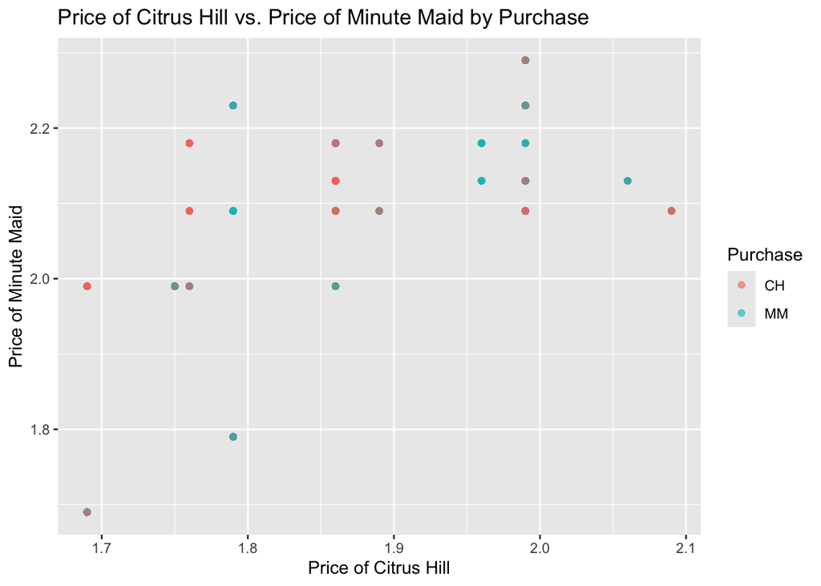

```r
ggplot(OJ, aes(x = PriceCH, y = PriceMM, color = Purchase)) +
  geom_point(alpha = 0.6) +
  ggtitle("Price of Citrus Hill vs. Price of Minute Maid by Purchase") +
  xlab("Price of Citrus Hill") + ylab("Price of Minute Maid")
```

In this scatter plot, we compare the prices of Citrus Hill and Minute Maid with respect to the purchases. Points are colored by Purchase, allowing us to see the relationship between the prices and the purchase decision. The scatter plot visualizes the relationship between the prices of Citrus Hill (x-axis) and Minute Maid (y-axis) for different purchase decisions. Points are color-coded by the product purchased (CH or MM). There is some overlap between the two products, but it is evident that lower prices for one product might influence the decision to purchase the other.

### Density Plots: Price of Citrus Hill vs. Price of Minute Maid by Purchase

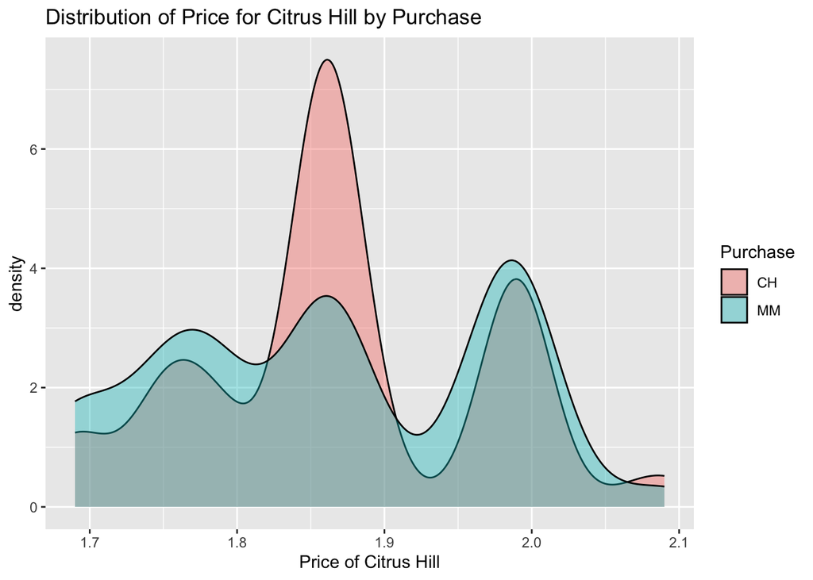

```r
ggplot(OJ, aes(x = PriceCH, fill = Purchase)) +
  geom_density(alpha = 0.4) +
  ggtitle("Distribution of Price for Citrus Hill by Purchase") +
  xlab("Price of Citrus Hill")
```

The density plot shows the distribution of prices for Citrus Hill (CH), separated by the product purchased (either Citrus Hill (CH) or Minute Maid (MM)), using different colors. The x-axis represents the price of Citrus Hill, while the y-axis indicates the density, or the relative frequency of different prices in the dataset.

- The red area represents customers who purchased Citrus Hill at various price points, and the teal area represents those who purchased Minute Maid.
- The peak for Citrus Hill purchases (red) occurs around a price of 1.9, indicating that customers tend to buy Citrus Hill more frequently at this price range.
- Minute Maid purchases (teal) are more spread out, with some preference for lower prices of Citrus Hill (1.7 to 1.8) and higher prices (around 2.0), possibly indicating that when Citrus Hill is priced low or high, more customers opt for Minute Maid. This visualization helps to understand how the pricing of Citrus Hill influences whether customers purchase it or opt for its competitor.

### Density Plots: Price for minute maid by purchase

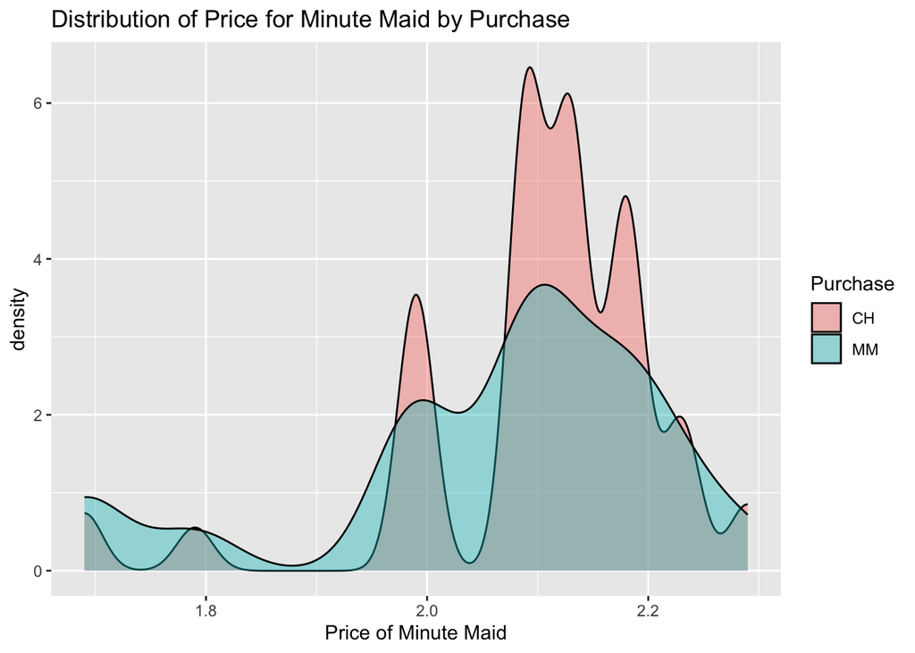

```r
ggplot(OJ, aes(x = PriceMM, fill = Purchase)) +
  geom_density(alpha = 0.4) +
  ggtitle("Distribution of Price for Minute Maid by Purchase") +
  xlab("Price of Minute Maid")
```

This density plot shows the price distribution of Minute Maid purchases by two groups: CH (red) and MM (blue). Both groups frequently buy around the 2.0–2.2 price range, with CH purchases being more concentrated around specific price points (2.0 and 2.1). MM purchases have a wider spread, including some lower prices (around 1.7), indicating more variability in purchase prices compared to CH. The overlap suggests shared popular price points, but MM appears more price-flexible.

## Building the Initial Decision Tree Model

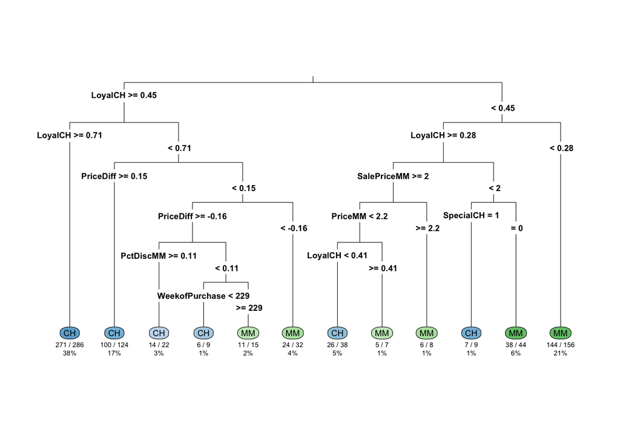

```r
# Build the Decision Tree model
tree_model <- rpart(Purchase ~ ., data = train_data, method = "class")

# Plot the Decision Tree
rpart.plot(tree_model, type = 3, extra = 102, under = TRUE, fallen.leaves = TRUE)
```

The Decision Tree is built using the rpart function. A Decision Tree works by splitting the data at each node based on the feature that best separates the classes (Citrus Hill and Minute Maid) using criteria like Gini Impurity. The resulting tree is plotted to visualize how the features (e.g., prices, demographics) are used to make predictions at each step. Interpretation of the Tree - **Nodes**: Each internal node represents a decision rule based on a feature. - **Branches**: Each branch represents the outcome of the decision (true or false). - **Leaves**: The terminal nodes (leaves) display the predicted class for the samples that reach them.

For customers with `LoyalCH` below 0.45, the tree uses `LoyalCH` thresholds at 0.28 and conditions based on `SalePriceMM` and `SpecialCH` to make classifications. Each endpoint represents a final classification into “CH” or “MM,” showing the number and percentage of instances in that category. This structure indicates that `LoyalCH` is a crucial determinant in the model, influencing classification outcomes across both high and low loyalty levels.

## Evaluating the Model

```r
# Evaluate the model on the test data
test_pred <- predict(tree_model, newdata = test_data, type = "class")
confusionMatrix(test_pred, test_data$Purchase)
```

```
## Confusion Matrix and Statistics
##
##           Reference
## Prediction  CH  MM
##         CH 169  33
##         MM  26  92
##
##                Accuracy : 0.8156
##                  95% CI : (0.7687, 0.8566)
##     No Information Rate : 0.6094
##     P-Value [Acc > NIR] : 1.373e-15
##
##                   Kappa : 0.6088
##
##  Mcnemar's Test P-Value : 0.4347
##
##             Sensitivity : 0.8667
##             Specificity : 0.7360
##          Pos Pred Value : 0.8366
##          Neg Pred Value : 0.7797
##              Prevalence : 0.6094
##          Detection Rate : 0.5281
##    Detection Prevalence : 0.6312
##       Balanced Accuracy : 0.8013
##
##        'Positive' Class : CH
##
```

```r
# Initial accuracy
initial_accuracy <- sum(test_pred == test_data$Purchase) / nrow(test_data)
print(paste("Initial Accuracy:", round(initial_accuracy * 100, 2), "%"))
```

```
## [1] "Initial Accuracy: 81.56 %"
```

Explanation:

### 1. **Confusion Matrix Overview**

The confusion matrix presents a summary of the prediction results of a classification model. In this case, you have two classes: **CH** (presumably representing one category) and **MM** (representing another category). The matrix is structured as follows:

|  | Reference CH | Reference MM |
| --- | --- | --- |
| **Predicted CH** | 169 | 33 |
| **Predicted MM** | 26 | 92 |

### 2. **Model Performance Metrics**

**Accuracy**: The proportion of correct predictions (both true positives and true negatives) among the total predictions.

- **Calculation**:
  $$\text{Accuracy} = \frac{TP + TN}{TP + TN + FP + FN} = \frac{169 +
  92}{169 + 33 + 26 + 92} = 0.8156 \text{ or } 81.56\%$$
- **Interpretation**: About 81.56% of the total predictions made by the model were correct.

**95% Confidence Interval (CI)**: - **Interpretation**: This interval (0.7687, 0.8566) indicates that we can be 95% confident that the true accuracy of the model lies within this range.

**No Information Rate (NIR)**: The accuracy expected if predictions were made solely based on the most frequent class (in this case, CH). - **Value**: 0.6094 indicates that if you simply predicted the most common class, you would be correct about 60.94% of the time.

**P-Value [Acc > NIR]**: - **Value**: 1.373e-15 indicates that the model’s accuracy is significantly better than the no information rate, suggesting that the model is effective.

### 3. **Kappa Statistic**

Kappa measures the agreement between the predicted and actual classifications, correcting for chance. - **Value**: 0.6088, indicating a moderate level of agreement beyond chance. Values closer to 1 imply better agreement.

### 4. **Mcnemar’s Test P-Value**

- **Value**: 0.4347 indicates no significant difference in the error rates of the two classes, suggesting that the model does not favor one class over the other.

### 9. **Prevalence**

The proportion of actual positive cases in the dataset. - **Value**: 0.6094 indicates that approximately 60.94% of the instances are actually CH.

### 12. **Balanced Accuracy**

The average of sensitivity and specificity. - **Calculation**:
$$\text{Balanced Accuracy} = \frac{\text{Sensitivity} +
\text{Specificity}}{2} = \frac{0.8667 + 0.7360}{2} = 0.8013 \text{ or }
80.13\%$$
- **Interpretation**: This metric accounts for imbalanced datasets, providing a more nuanced view of model performance.

### 13. **Positive Class**

- **Value**: CH is identified as the positive class, meaning the model’s performance metrics primarily focus on predicting this class.

### Summary

In summary, the model shows good overall accuracy (**81.56%**) and a strong ability to correctly identify positive cases (CH) with a sensitivity of **86.67%**. The Kappa statistic and confidence intervals suggest that the model’s performance is statistically significant and that it performs better than random guessing. The balance between sensitivity and specificity is relatively good, making this model a reliable choice for the task at hand.

## Feature Importance

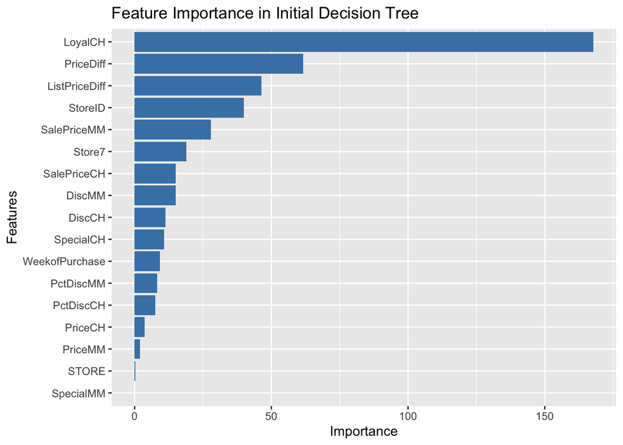

```r
var_imp <- as.data.frame(varImp(tree_model, scale = FALSE))
var_imp$Variable <- rownames(var_imp)
ggplot(var_imp, aes(x = reorder(Variable, Overall), y = Overall)) +
  geom_bar(stat = "identity", fill = "steelblue") +
  coord_flip() +
  xlab("Features") + ylab("Importance") +
  ggtitle("Feature Importance in Initial Decision Tree")
```

This feature importance plot shows which variables contributed the most to the Decision Tree splits. Variables with higher importance values played a more significant role in determining whether a customer purchased Citrus Hill or Minute Maid. This bar chart displays the feature importance rankings from an initial decision tree model. “LoyalCH” has the highest importance, suggesting that customer loyalty has the strongest impact on the model’s predictions. Other key features, such as “PriceDiff” and “ListPriceDiff,” also have significant influence, while features like “STORE” and “SpecialMM” have minimal impact, indicating they contribute less to the model’s predictive power.

## Improving the Model: Hyperparameter Tuning

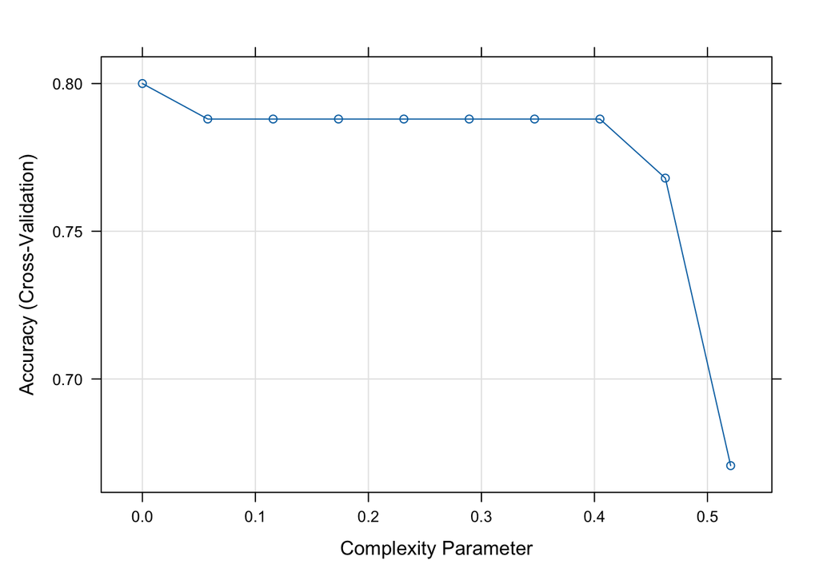

```r
# Tune the model with cross-validation
set.seed(123)
tree_tuned <- train(Purchase ~ ., data = train_data, method = "rpart",
                    trControl = trainControl(method = "cv", number = 10),
                    tuneLength = 10)

# Plot the tuning results
plot(tree_tuned)
```

## Final Decision Tree and Evaluation

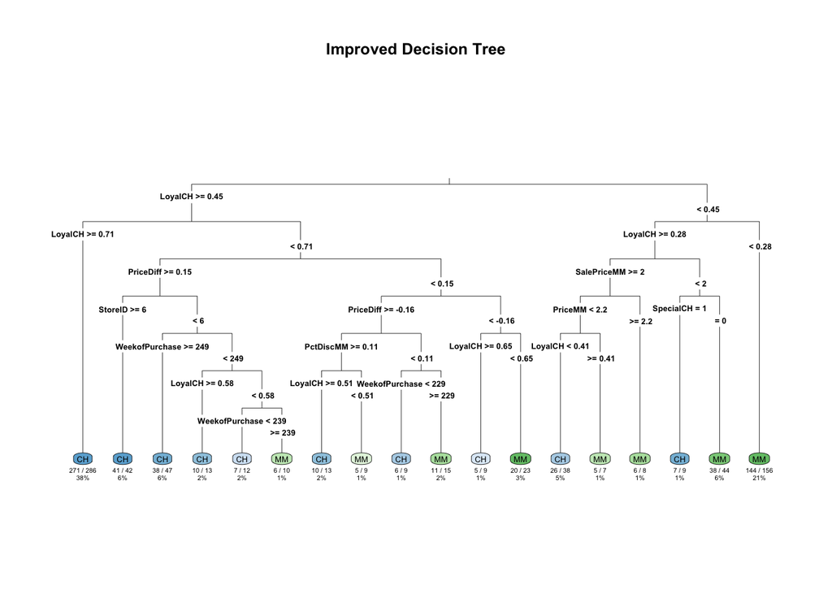

```r
# Build the final tuned Decision Tree
final_tree_model <- rpart(Purchase ~ ., data = train_data, method = "class",
                          control = rpart.control(cp = tree_tuned$bestTune$cp))

# Plot the final tree
rpart.plot(final_tree_model, type = 3, extra = 102, under = TRUE, fallen.leaves = TRUE,
           main = "Improved Decision Tree")
```

```r
# Evaluate the final model
final_test_pred <- predict(final_tree_model, newdata = test_data, type = "class")
confusionMatrix(final_test_pred, test_data$Purchase)
```

```
## Confusion Matrix and Statistics
##
##           Reference
## Prediction  CH  MM
##         CH 165  31
##         MM  30  94
##
##                Accuracy : 0.8094
##                  95% CI : (0.762, 0.8509)
##     No Information Rate : 0.6094
##     P-Value [Acc > NIR] : 1.07e-14
##
##                   Kappa : 0.599
##
##  Mcnemar's Test P-Value : 1
##
##             Sensitivity : 0.8462
##             Specificity : 0.7520
##          Pos Pred Value : 0.8418
##          Neg Pred Value : 0.7581
##              Prevalence : 0.6094
##          Detection Rate : 0.5156
##    Detection Prevalence : 0.6125
##       Balanced Accuracy : 0.7991
##
##        'Positive' Class : CH
##
```

```r
# Final accuracy
final_accuracy <- sum(final_test_pred == test_data$Purchase) / nrow(test_data)
print(paste("Final Accuracy:", round(final_accuracy * 100, 2), "%"))
```

```
## [1] "Final Accuracy: 80.94 %"
```

### Confusion Matrix and Performance Metrics

#### 1. **Confusion Matrix Overview**

- **Structure**:

  |  | Reference CH | Reference MM |
  | --- | --- | --- |
  | **Predicted CH** | 165 | 31 |
  | **Predicted MM** | 30 | 94 |

#### 2. **Model Performance Metrics**

- **Accuracy**: 80.94% (correct predictions among total).
- **95% Confidence Interval (CI)**: (0.762, 0.8509) - true accuracy likely within this range.
- **No Information Rate (NIR)**: 60.94% - accuracy if only predicting the most frequent class.
- **P-Value [Acc > NIR]**: 1.07e-14 - model significantly outperforms random guessing.

#### 3. **Kappa Statistic**

- **Value**: 0.599 - indicates moderate agreement beyond chance.

#### 4. **Mcnemar’s Test P-Value**

- **Value**: 1 - no significant difference in error rates for classes.

#### 5. **Sensitivity (True Positive Rate)**

- **Value**: 84.62% - accurately identifies actual CH instances.

#### 6. **Specificity (True Negative Rate)**

- **Value**: 75.20% - accurately identifies actual MM instances.

#### 7. **Positive Predictive Value (PPV)**

- **Value**: 84.18% - proportion of predicted CH that are actually CH.

#### 8. **Negative Predictive Value (NPV)**

- **Value**: 75.81% - proportion of predicted MM that are actually MM.

#### 9. **Prevalence**

- **Value**: 60.94% - indicates the proportion of actual CH cases.

#### 11. **Detection Prevalence**

- **Value**: 61.25% - proportion of instances predicted as CH.

#### 12. **Balanced Accuracy**

- **Value**: 79.91% - average of sensitivity and specificity.

#### 13. **Positive Class**

- **Class Identified**: CH is considered the positive class for performance metrics.

### Summary

In summary, this model shows an overall accuracy of **80.94%**, with a strong sensitivity of **84.62%**, indicating that it effectively identifies positive cases (CH). The model also performs well in terms of specificity (**75.20%**) and Kappa statistic (**0.599**), which suggests a moderate level of agreement beyond chance. The confidence interval and P-values indicate that the model’s performance is statistically significant and that it performs better than random guessing. Overall, Model 2 demonstrates reliable predictive capability for the task at hand. This Model demonstrates reliable predictive capability for identifying the positive class (CH).

# Comparative Analysis of Model Performance

## Model 1 Metrics (Before Cross-validation)

- **Accuracy**: 81.56%
- **Sensitivity (True Positive Rate)**: 86.67%
- **Specificity (True Negative Rate)**: 73.60%
- **Positive Predictive Value (PPV)**: 83.66%
- **Negative Predictive Value (NPV)**: 77.97%
- **Kappa Statistic**: 0.6088
- **Balanced Accuracy**: 80.13%
- **95% Confidence Interval (CI)**: (0.7687, 0.8566)

## Model 2 Metrics (After Cross-validation)

- **Accuracy**: 80.94%
- **Sensitivity (True Positive Rate)**: 84.62%
- **Specificity (True Negative Rate)**: 75.20%
- **Positive Predictive Value (PPV)**: 84.18%
- **Negative Predictive Value (NPV)**: 75.81%
- **Kappa Statistic**: 0.599
- **Balanced Accuracy**: 79.91%
- **95% Confidence Interval (CI)**: (0.762, 0.8509)

## Key Comparisons

1. **Accuracy**: Model 1 has a slightly higher accuracy (81.56%) compared to Model 2 (80.94%).
2. **Sensitivity**: Model 1 also outperforms Model 2 in sensitivity (86.67% vs. 84.62%), indicating it is better at identifying actual positive cases (CH).
3. **Specificity**: Model 2 has a higher specificity (75.20% vs. 73.60%), meaning it is slightly better at identifying actual negative cases (MM).
4. **Positive Predictive Value (PPV)**: Model 2 performs better in terms of PPV (84.18% vs. 83.66%), suggesting it is more reliable when predicting CH instances.
5. **Negative Predictive Value (NPV)**: Model 1 has a better NPV (77.97% vs. 75.81%), indicating it is more effective at predicting negative instances.
6. **Kappa Statistic**: Model 1 shows a marginally better Kappa statistic (0.6088 vs. 0.599), indicating slightly stronger agreement beyond chance.
7. **Balanced Accuracy**: Model 1 has a better balanced accuracy (80.13% vs. 79.91%), highlighting a more favorable performance considering both classes.
8. **Confidence Intervals**: Both models show overlapping confidence intervals, but Model 1’s is slightly higher, reinforcing its reliability.

## Conclusion

In terms of general applicability, **Model 1 is recommended for scenarios where accurately identifying positive cases is critical**, while **Model 2 may be preferable in contexts where correctly predicting negative instances is more important**. Ultimately, the choice between models should consider the specific requirements of the application, particularly the costs associated with false positives and false negatives.